# ITVEDANT

PROJECT 2020-21 Topic:- Data of "COVID-19 World Vaccination Progress Data:- Of 26-01-2021 Version-16 Source:- Our World in Data GitHub repository for covid-19 Name: Guided by: Jayant Sathawane Chetna Padiya mam Importing all Module NumPy is a Python library used for working with arrays Pandas is high-performance data structures and data analysis tools Matplotlib is a plotting library for the Python programming language and its numerical mathematics extension NumPy. Seaborn provides a high-level interface for drawing attractive and informative statistical graphics.

```python
import numpy as np
import pandas as pd
import matplotlib.pyplot as plt
import seaborn as sns
```

Reading or Assigning the excel file data to store in (data) variable

```python
data=pd.read_csv("data/country_vaccinations.csv")
```

```python
data
```

|  | country | iso_code | date | total_vaccinations | people_vaccinated | people_fully_vaccinated | daily_vaccinations_raw | daily_vaccinations | total_vaccinations_per_hundred | people_vaccinated_per_hundred | people_fully_vaccinated_per_hundred | daily_vaccinations_per_million | vaccines | source_name | source_website |
| --- | --- | --- | --- | --- | --- | --- | --- | --- | --- | --- | --- | --- | --- | --- | --- |
| 0 | Argentina | ARG | 2020-12-29 | 700.0 | NaN | NaN | NaN | NaN | 0.00 | NaN | NaN | NaN | Sputnik V | Ministry of Health | http://datos.salud.gob.ar/dataset/vacunas-cont... |
| 1 | Argentina | ARG | 2020-12-30 | NaN | NaN | NaN | NaN | 15656.0 | NaN | NaN | NaN | 346.0 | Sputnik V | Ministry of Health | http://datos.salud.gob.ar/dataset/vacunas-cont... |
| 2 | Argentina | ARG | 2020-12-31 | 32013.0 | NaN | NaN | NaN | 15656.0 | 0.07 | NaN | NaN | 346.0 | Sputnik V | Ministry of Health | http://datos.salud.gob.ar/dataset/vacunas-cont... |
| 3 | Argentina | ARG | 2021-01-01 | NaN | NaN | NaN | NaN | 11070.0 | NaN | NaN | NaN | 245.0 | Sputnik V | Ministry of Health | http://datos.salud.gob.ar/dataset/vacunas-cont... |
| 4 | Argentina | ARG | 2021-01-02 | NaN | NaN | NaN | NaN | 8776.0 | NaN | NaN | NaN | 194.0 | Sputnik V | Ministry of Health | http://datos.salud.gob.ar/dataset/vacunas-cont... |
| ... | ... | ... | ... | ... | ... | ... | ... | ... | ... | ... | ... | ... | ... | ... | ... |
| 1497 | Wales | NaN | 2021-01-20 | 190831.0 | 190435.0 | 396.0 | 14645.0 | 11105.0 | 6.05 | 6.04 | 0.01 | 3522.0 | Oxford/AstraZeneca, Pfizer/BioNTech | Government of the United Kingdom | https://coronavirus.data.gov.uk/details/health... |
| 1498 | Wales | NaN | 2021-01-21 | 212732.0 | 212317.0 | 415.0 | 21901.0 | 12318.0 | 6.75 | 6.73 | 0.01 | 3907.0 | Oxford/AstraZeneca, Pfizer/BioNTech | Government of the United Kingdom | https://coronavirus.data.gov.uk/details/health... |
| 1499 | Wales | NaN | 2021-01-22 | 241016.0 | 240547.0 | 469.0 | 28284.0 | 15148.0 | 7.64 | 7.63 | 0.01 | 4804.0 | Oxford/AstraZeneca, Pfizer/BioNTech | Government of the United Kingdom | https://coronavirus.data.gov.uk/details/health... |
| 1500 | Wales | NaN | 2021-01-23 | 265054.0 | 264538.0 | 516.0 | 24038.0 | 17371.0 | 8.41 | 8.39 | 0.02 | 5510.0 | Oxford/AstraZeneca, Pfizer/BioNTech | Government of the United Kingdom | https://coronavirus.data.gov.uk/details/health... |
| 1501 | Wales | NaN | 2021-01-24 | 271376.0 | 270833.0 | 543.0 | 6322.0 | 17063.0 | 8.61 | 8.59 | 0.02 | 5412.0 | Oxford/AstraZeneca, Pfizer/BioNTech | Government of the United Kingdom | https://coronavirus.data.gov.uk/details/health... |

1502 rows × 15 columns

Getting all Columns in file

```python
data.info()           #data.columns()
```

```
<class 'pandas.core.frame.DataFrame'>
RangeIndex: 1502 entries, 0 to 1501
Data columns (total 15 columns):
 #   Column                               Non-Null Count  Dtype
---  ------                               --------------  -----
 0   country                              1502 non-null   object
 1   iso_code                             1337 non-null   object
 2   date                                 1502 non-null   object
 3   total_vaccinations                   1017 non-null   float64
 4   people_vaccinated                    965 non-null    float64
 5   people_fully_vaccinated              298 non-null    float64
 6   daily_vaccinations_raw               827 non-null    float64
 7   daily_vaccinations                   1442 non-null   float64
 8   total_vaccinations_per_hundred       1017 non-null   float64
 9   people_vaccinated_per_hundred        965 non-null    float64
 10  people_fully_vaccinated_per_hundred  298 non-null    float64
 11  daily_vaccinations_per_million       1442 non-null   float64
 12  vaccines                             1502 non-null   object
 13  source_name                          1502 non-null   object
 14  source_website                       1502 non-null   object
dtypes: float64(9), object(6)
memory usage: 140.9+ KB
```

Checking size of file

```python
data.shape    #input checking
```

```
(1502, 15)
```

Getting all Important Mathematical calculations like total,mean,standard deviation,min,max

```python
data.describe()
```

|  | total_vaccinations | people_vaccinated | people_fully_vaccinated | daily_vaccinations_raw | daily_vaccinations | total_vaccinations_per_hundred | people_vaccinated_per_hundred | people_fully_vaccinated_per_hundred | daily_vaccinations_per_million |
| --- | --- | --- | --- | --- | --- | --- | --- | --- | --- |
| count | 1.017000e+03 | 9.650000e+02 | 2.980000e+02 | 8.270000e+02 | 1.442000e+03 | 1017.000000 | 965.000000 | 298.000000 | 1442.000000 |
| mean | 6.444783e+05 | 6.097208e+05 | 1.679639e+05 | 4.918421e+04 | 4.334959e+04 | 2.657266 | 2.525834 | 0.643926 | 1525.589459 |
| std | 2.057426e+06 | 1.849519e+06 | 4.578437e+05 | 1.384141e+05 | 1.165367e+05 | 5.502249 | 4.912769 | 1.729458 | 3269.660451 |
| min | 0.000000e+00 | 0.000000e+00 | 1.000000e+00 | 0.000000e+00 | 1.000000e+00 | 0.000000 | 0.000000 | 0.000000 | 0.000000 |
| 25% | 1.743500e+04 | 1.776700e+04 | 1.887000e+03 | 1.621500e+03 | 1.659750e+03 | 0.260000 | 0.260000 | 0.012500 | 269.000000 |
| 50% | 7.103000e+04 | 7.527600e+04 | 8.407000e+03 | 7.759000e+03 | 5.567000e+03 | 0.850000 | 0.850000 | 0.070000 | 666.500000 |
| 75% | 3.096200e+05 | 3.382520e+05 | 1.011120e+05 | 3.785100e+04 | 2.797975e+04 | 2.060000 | 2.050000 | 0.657500 | 1122.000000 |
| max | 2.273424e+07 | 1.925228e+07 | 3.346390e+06 | 1.561585e+06 | 1.126251e+06 | 44.880000 | 30.770000 | 14.110000 | 30869.000000 |

Checking number of zeros or empty cells in columns

```python
data.isnull().sum()    #empty cells
```

```
country                                   0
iso_code                                165
date                                      0
total_vaccinations                      485
people_vaccinated                       537
people_fully_vaccinated                1204
daily_vaccinations_raw                  675
daily_vaccinations                       60
total_vaccinations_per_hundred          485
people_vaccinated_per_hundred           537
people_fully_vaccinated_per_hundred    1204
daily_vaccinations_per_million           60
vaccines                                  0
source_name                               0
source_website                            0
dtype: int64
```

Getting all Countries name followed by no. of country calculation

```python
data['country'].unique()
```

```
array(['Argentina', 'Austria', 'Bahrain', 'Belgium', 'Brazil', 'Bulgaria',
       'Canada', 'Chile', 'China', 'Costa Rica', 'Croatia', 'Cyprus',
       'Czechia', 'Denmark', 'Ecuador', 'England', 'Estonia', 'Finland',
       'France', 'Germany', 'Gibraltar', 'Greece', 'Hungary', 'Iceland',
       'India', 'Indonesia', 'Ireland', 'Isle of Man', 'Israel', 'Italy',
       'Kuwait', 'Latvia', 'Lithuania', 'Luxembourg', 'Malta', 'Mexico',
       'Netherlands', 'Northern Ireland', 'Norway', 'Oman', 'Panama',
       'Poland', 'Portugal', 'Romania', 'Russia', 'Saudi Arabia',
       'Scotland', 'Serbia', 'Seychelles', 'Singapore', 'Slovakia',
       'Slovenia', 'Spain', 'Sweden', 'Switzerland', 'Turkey',
       'United Arab Emirates', 'United Kingdom', 'United States', 'Wales'],
      dtype=object)
```

```python
len(data['country'].unique())
```

```
60
```

Datas taken on the days listed followed by number of days data has been taken counted

```python
data['date'].unique()
```

```
array(['2020-12-29', '2020-12-30', '2020-12-31', '2021-01-01',
       '2021-01-02', '2021-01-03', '2021-01-04', '2021-01-05',
       '2021-01-06', '2021-01-07', '2021-01-08', '2021-01-09',
       '2021-01-10', '2021-01-11', '2021-01-12', '2021-01-13',
       '2021-01-14', '2021-01-15', '2021-01-16', '2021-01-17',
       '2021-01-18', '2021-01-19', '2021-01-20', '2021-01-21',
       '2021-01-22', '2021-01-23', '2021-01-24', '2021-01-25',
       '2020-12-23', '2020-12-24', '2020-12-25', '2020-12-26',
       '2020-12-27', '2020-12-28', '2020-12-14', '2020-12-15',
       '2020-12-16', '2020-12-17', '2020-12-18', '2020-12-19',
       '2020-12-20', '2020-12-21', '2020-12-22', '2020-12-13'],
      dtype=object)
```

```python
len(data['date'].unique())
```

```
44
```

# Relation Plot

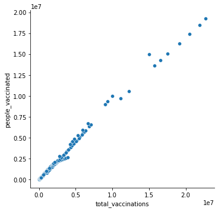

```python
sns.relplot(y="people_vaccinated",x="total_vaccinations",data=data)
plt.show()
```

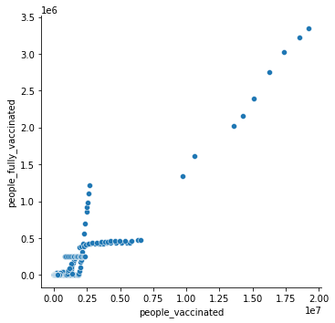

```python
sns.relplot(y="people_fully_vaccinated",x="people_vaccinated",data=data)   #data graph is there but what about countries
plt.show()
```

#Scatter Plot

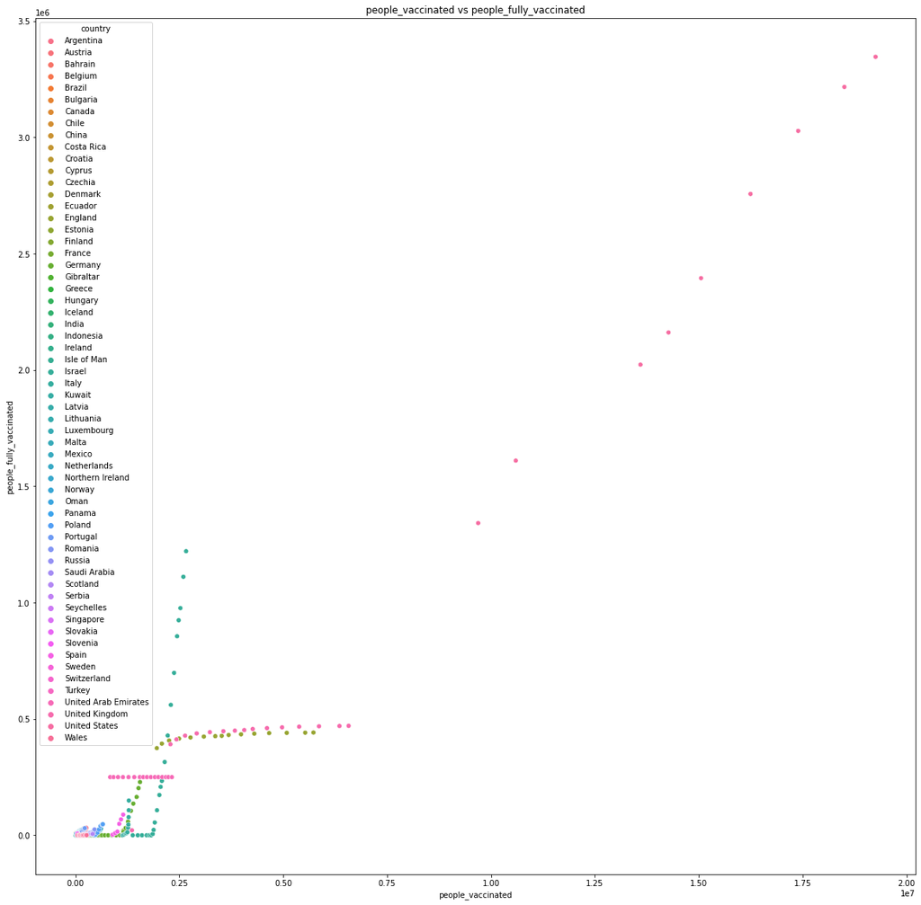

```python
plt.figure(figsize=(20,20))
plt.title("people_vaccinated vs people_fully_vaccinated")
sns.scatterplot(data=data,x='people_vaccinated',y='people_fully_vaccinated',hue='country')      #it show according to countries
plt.show()
```

# BoxPlot

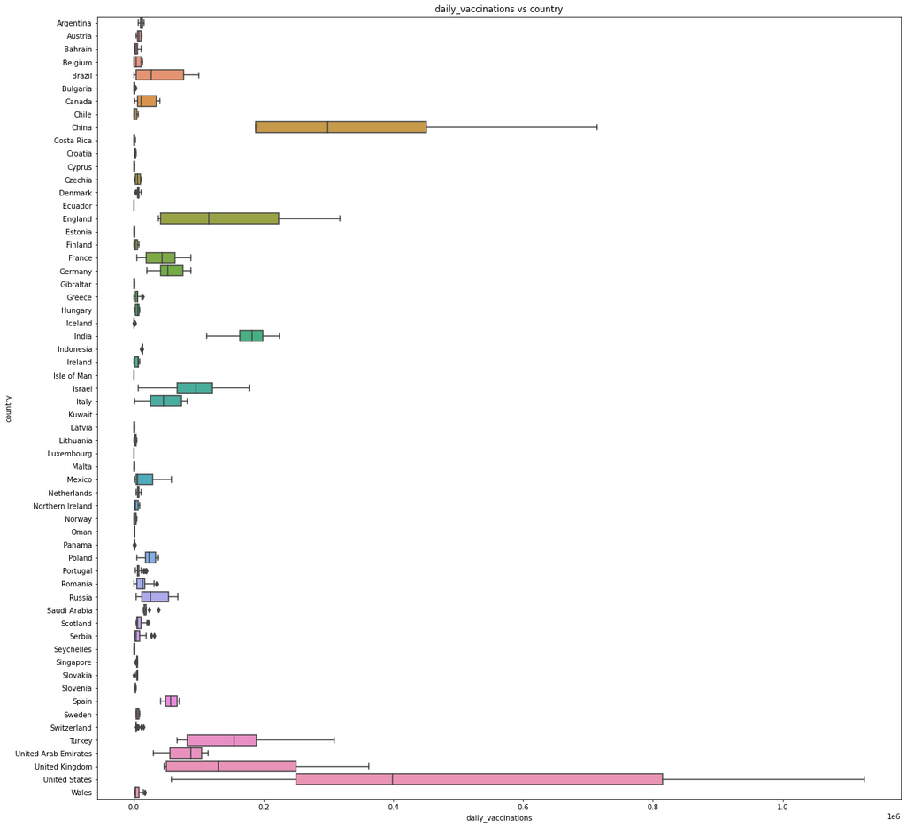

```python
plt.figure(figsize=(20,20))
plt.title("daily_vaccinations vs country")
sns.boxplot(data=data,x='daily_vaccinations',y='country')
plt.show()
```

#Horizontal Count Plot

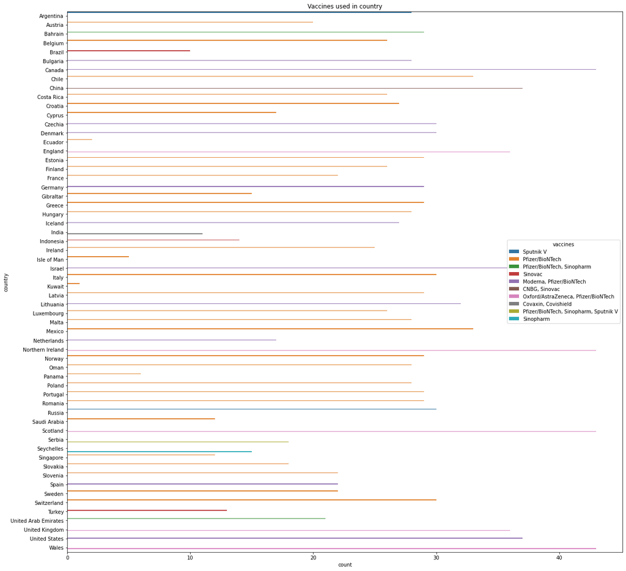

```python
plt.figure(figsize=(20,20))
plt.title("Vaccines used in country")
sns.countplot(data=data,y="country",hue="vaccines")
plt.show()
```

# PIE Chart

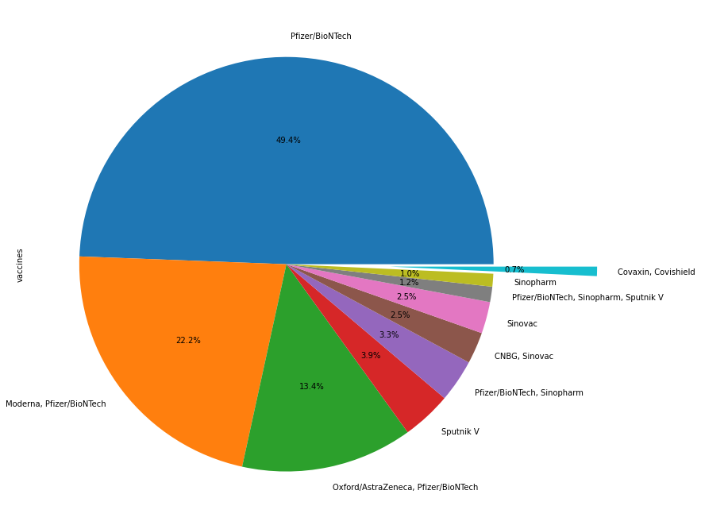

```python
plt.figure(figsize=(12,12))
data['vaccines'].value_counts().plot.pie(autopct="%1.1f%%",explode=(0,0,0,0,0,0,0,0,0,0.5))
#plt.title("Body_style count with percenteage")
plt.show()
```

# Scatter plot

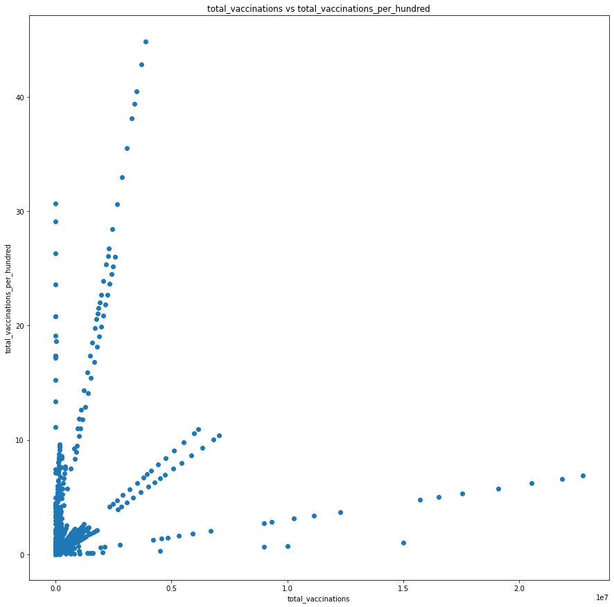

```python
plt.figure(figsize=(15,15))
plt.title("total_vaccinations vs total_vaccinations_per_hundred")
plt.scatter(x=data['total_vaccinations'],y=data['total_vaccinations_per_hundred'])
plt.ylabel("total_vaccinations_per_hundred")
plt.xlabel("total_vaccinations")
plt.show()
```

# Scatter plot with hue

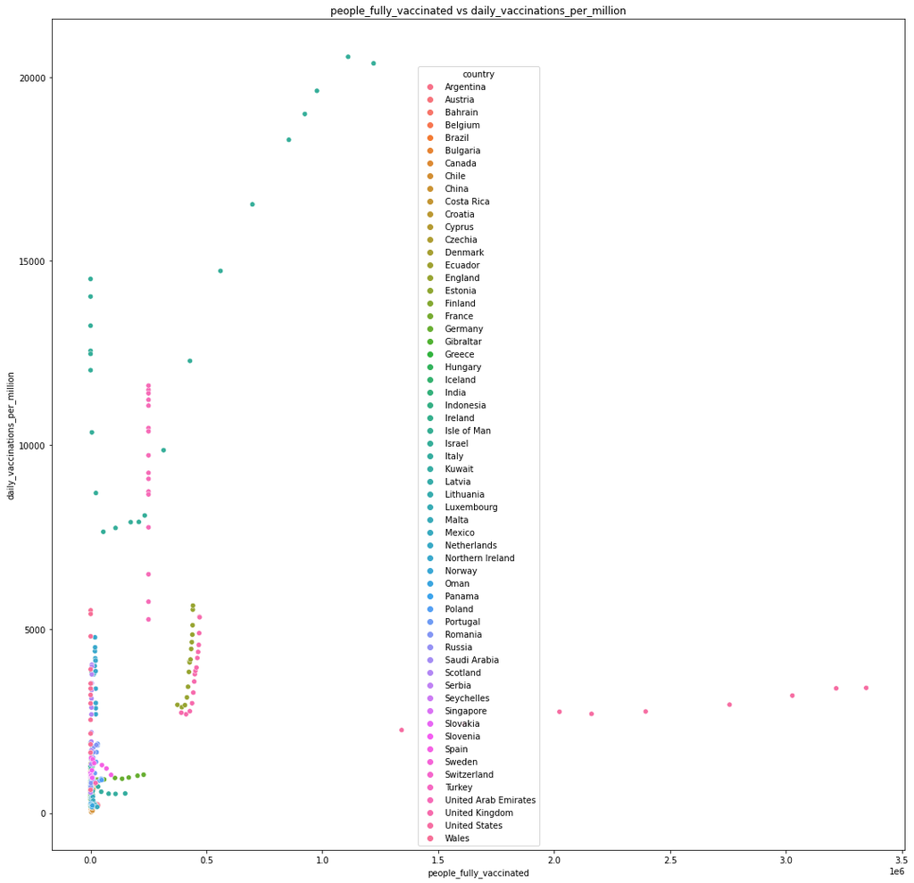

```python
plt.figure(figsize=(18,18))
plt.title("people_fully_vaccinated vs daily_vaccinations_per_million")
sns.scatterplot(data=data,x='people_fully_vaccinated',y='daily_vaccinations_per_million',hue='country') #it show according to countries
plt.show()
```

#Heatmap (for correlation analysis)

```python
corr=data.corr()
```

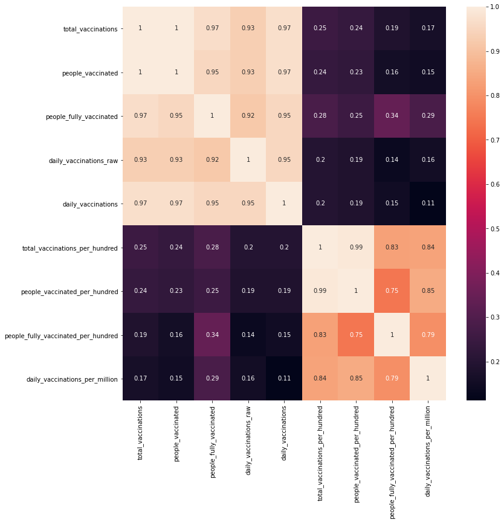

```python
plt.figure(figsize=(12,12))
sns.heatmap(corr,annot=True)
plt.show()
```

#Violin Plot

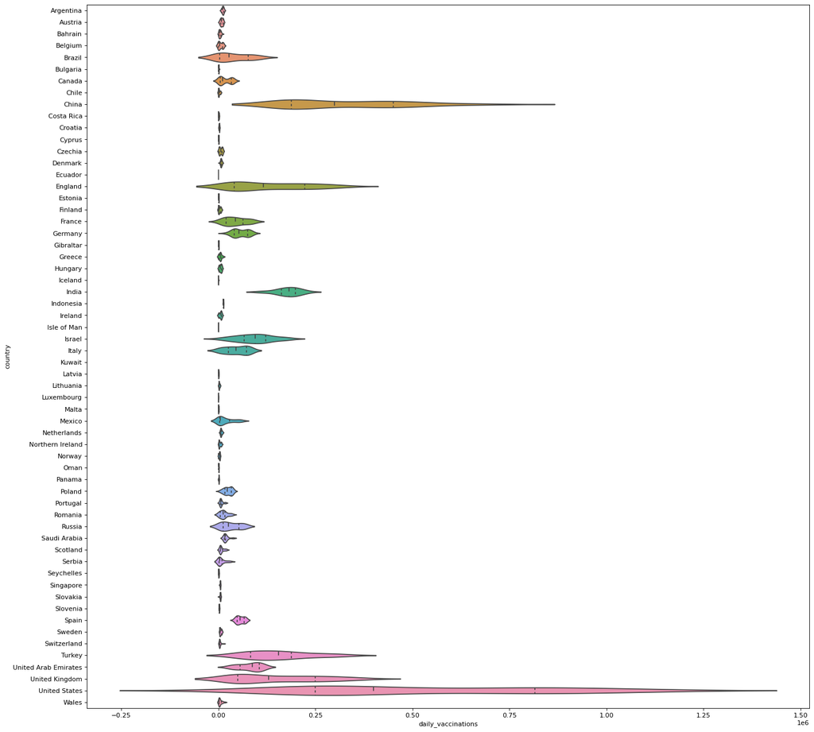

```python
plt.figure(figsize=(20,20), dpi= 80)
sns.violinplot(y='country', x='daily_vaccinations', data=data, scale='width', inner='quartile')
plt.show()
```